# Magic keywords

## Timing code

To check how long a function is running, there is the `timeit` magic command. It can either be applied to one line through using one `%` before it or it can be applied on a whole cell through using `%%`.

First let's check how long our function for calculating the Fibonacci number is running here. One time we have the recursive version of the function as `fibo1()` and the second function `fibo2()` is the closed form of the calculation.

```python
from math import sqrt

# Recursive Fibonacci number
def fibo1(n):
    if n == 0:
        return 0
    elif n == 1:
        return 1
    return fibo1(n-1) + fibo1(n-2)

# Closed form
def fibo2(n):
    return ((1+sqrt(5))**n-(1-sqrt(5))**n)/(2**n*sqrt(5))
```

```python
%timeit fibo1(20)
```

```
2.32 ms ± 54.2 µs per loop (mean ± std. dev. of 7 runs, 100 loops each)
```

```python
%timeit fibo2(20)
```

```
1.1 µs ± 40.6 ns per loop (mean ± std. dev. of 7 runs, 1000000 loops each)
```

By comparing those two functions, we can see that there is a difference in how long it takes the functions to calculate the 20th Fibonacci number.

Next we are going to test the `timeit` function for whole text cells. Therefore we will use `%%`.

```python
import random
```

```python
%%timeit
prize = 0
for ii in range(100):
    # roll a dice
    roll = random.randint(1,6)
    if roll % 2 == 0:
        prize += roll
    else:
        prize -= 1
```

```
102 µs ± 8.51 µs per loop (mean ± std. dev. of 7 runs, 10000 loops each)
```

```python
%%timeit
rolls = (random.randint(1,6) for _ in range(100))
prize = sum(roll if roll % 2 == 0 else -1 for roll in rolls)
```

```
111 µs ± 14.4 µs per loop (mean ± std. dev. of 7 runs, 10000 loops each)
```

## Embedding visualizations

In notebooks you can embed images along with text and code. To make use of this we can for example use `matplotlib`.

For setting up `matplotlib` for interactive use in the notebook we can use `%matplotlib`. To render images directly in the notebook instead of (what is set as default) rendering them in their own window we use `%matplotlib inline`.

To prevent images from looking blurry on high resolution screens like retina displays we use `%config InlineBackend.figure_format = 'retina'` after the `%matplot inline` command.

```python
%matplotlib inline
%config InlineBackend.figure_format = 'retina'

import matplotlib.pyplot as plt
import numpy as np
```

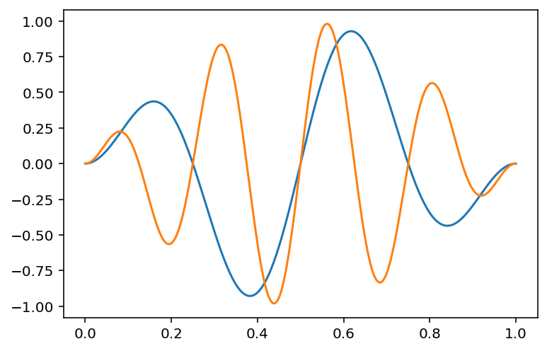

```python
x = np.linspace(0, 1, 300)
for w in range(2, 6, 2):
    plt.plot(x, np.sin(np.pi*x)*np.sin(2*w*np.pi*x))
```

## Debugging in the Notebook

To turn on the interactive debugger with the python kernel you can use the `%pdb` command. When you turned on the interactive debugger, you can inspect variables in the current namespace.

When an error occurs after activating the debugger, a prompt will open where you can inspect your code. To quit the debugger you can simply enter `q` in the prompt.

To get to know more about `pdb` you can read more in the [documentation](https://docs.python.org/3/library/pdb.html).

```python
%pdb
```

```
Automatic pdb calling has been turned ON
```

```python
number = 'hello'
sum(numbers)
```

```
---------------------------------------------------------------------------
NameError                                 Traceback (most recent call last)
<ipython-input-10-8a464e86a4ea> in <module>
      1 number = 'hello'
----> 2 sum(numbers)

NameError: name 'numbers' is not defined
```

```
> <ipython-input-10-8a464e86a4ea>(2)<module>()
      1 number = 'hello'
----> 2 sum(numbers)

ipdb> q
```

## More magic commands

To see more magic commands you can have a look [here](https://ipython.readthedocs.io/en/stable/interactive/magics.html).